# Evaluation report and metrics

5.2.0  
Evaluation report and metrics

- [ Index ]
- Introduction
  - Metrics
  - Classifier and regressor models
  - Input validation files
  - Output validation files for post-processing support
- Metrics
  - Computational complexity: MACC and cycles/MACC
  - Memory-related metrics
  - Classification accuracy (acc)
  - Mean Absolute Error (mae)
  - Root Mean Square Error (rmse)
  - L2 relative error (l2r)
  - Confusion matrix (CM)
- Use cases
  - 32b float model - Input samples only
  - 32b float model - Input/output samples
  - Quantized model - Input samples only
  - TFLite Quantized model - Input/output samples
  - Model with multiple IO
- Post-processing example
- References
- Revision history

# Evaluation report and metrics

X-CUBE-AI Expansion Package

r1.4

AI PLATFORM r5.2.0 (Embedded Inference Client API 1.1.0)

Command Line Interface r1.4.0

# Introduction

This article describes the different metrics which are computed and used to test and to evaluate the generated C-files (or C-model).

## Metrics

| metric | category | description | model type, format |
| --- | --- | --- | --- |
| `MACC` | perf | computational complexity | all models |
| `ROM/RAM` | memory | memory-related metrics | all models |
| `ACC` | perf/error | accuracy (Classification accuracy) | only classifier models (float and integer format) |
| `RMSE` | perf/error | Root Mean Square Error | all models |
| `MAE` | perf/error | Mean Absolute Error | all models |
| `L2r` | perf/error | L2 relative Error | all models |
| `CM` | perf/error | Confusion Matrix | only classifier models (float and integer format) |

Evaluation of the perf/error metrics are computed with the following data:

- `[I]` designates the list of the input samples which are used to feed the original model and the C-model. It can be provided by the user (see “inputs validation files”) or randomly generated.
- `[P]` designates the list of the predicted samples inferred by the C-model.
- `[R']` designates the list of the predicted samples inferred by the original model.
- {optional} `[R]` designates, the list of the predicted output samples provided by the user which are used as ground truth or reference values.

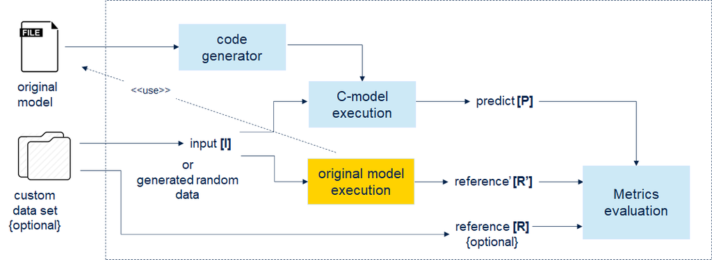

Figure 1: Metrics evaluation data flow

Results are summarized in a simple table.

```
Evaluation report (summary)
--------------------------------------------------------------------------------------------------------
Mode                 acc      rmse      mae       l2r       tensor
--------------------------------------------------------------------------------------------------------
x86 C-model #1       92.68%   0.053623  0.005785  0.340042  dense_4_nl [ai_float, (1, 1, 36), m_id=10]
original model #1    92.68%   0.053623  0.005785  0.340042  dense_4_nl [ai_float, (1, 1, 36), m_id=10]
X-cross #1           100.00%  0.000000  0.000000  0.000000  dense_4_nl [ai_float, (1, 1, 36), m_id=10]

L2r error : 1.11012369e-07 (expected to be < 0.01)
```

- `'X-cross'` line indicates the metrics which are evaluated with the `[P]` and `[R']` values. The predicted values `[R']` from the original model are considered as the **reference** values. If `[R]` is not provided, only `'X-cross'` metrics are computed else all metrics are reported for the `'C-model'` and `'original model'`. `'C-model'` refers to the execution of the *X86* or *STM32* generated C-model. In both case, the same validation flow is applied (refer to [[2]](https://www.st.com/resource/en/user_manual/dm00570145.pdf)).

**Note** — All input data and generated output data are always saved (without modification) in the particular files, see “Output validation files for post-processing support” section.

**Note** — Evaluation of a generated C-model is more accurate with the custom representative input values. Because the generated random samples are uniformly distributed with a fixed seed inside `'[-1.0, 1.0]'` range, and they are not necessarily representative of the input space of data used to train the model.

## Classifier and regressor models

In the case where a regressor model is considered by the validation engine, only the `'ACC'` and `'CM'` metrics are NOT computed, all other metrics are evaluated. According the predicted values (`[R']` or `[R]`), the type of the model is automatically detected. User has the possibility to force the computation of the `ACC`/`CM` metrics with the `'--classifier'` flag in the command line.

[output not shown]

## Input validation files

The user can provide the inputs and associated ground truth or reference values in a simple file (`'npz'` numpy format) or separated files (`'npy'` numpy format or `'csv'` format).

- `'csv'` files are the normal text files with a flattened version of the input (or output) tensors, one by line. Comma `','` separator is used to separate the values.
- `'npy'` files are the standard numpy binary format to store a single array.
- `'npz'` file is a standard numpy binary format to store several arrays. The following dict entries (or keys) are supported to store the data: `'x_test'` and `'y_test'` or `'in_0'` and `'out_0'` or `'m_inputs'` and `'m_outputs'` or `'m_inputs_1'` and `'m_outputs_1'`. For network with multiple IO, `'m_inputs_<idx>'` and `'m_outputs_<idx>'` keys with `idx` starting with `1` should be used.

32b float and int8/uint8 numbers are supported. For the csv files, a particular tag (`'dtype=uint8'` or `'dtype=int8'`) must be defined in the five first comment lines to indicate the type of the data, else 32b float number will be used.

```
# Example of csv file (32-b float number)
# comment line
-1.076007485389709473e+00,6.278980255126953125e+00,.. 3.949900865554809570e+00
1.160453605651855469e+01,1.707991600036621094e+01,.. 1.334794044494628906e+00
...
```

```
# Example of csv file (uint8 number)
# dtype=uint8
50, 65, 71, 71
4.800000000000000000e+01,6.700000000000000000e+01,7.300000000000000000e+01,6.700000000000000000e+01
...
```

- Lines from the `'csv'` file are always parsed as the 32b float numbers, after they are converted to int8/uint8 type if requested.
- For the quantized models, if a 32b float data set is used, a pre-process is applied to convert the data according the expected format. Same conversion is done for the outputs. Warning if `'uint8'` data are provided, and the requested quantized model expects `'int8'` or `'float32'` type an exception will be raised.
- For network with multiple IO, one `csv` file should be provided by input (respectively by output). The order in the CLI is used to know the index of the network inputs/outputs (name of the file is not considered). For the `npz` file, the index `<idx>` of the key will be used.

  ```
  $ stm32ai validate <model_file> -vi inputs.csv inputs_extra.csv -vo outputs.csv
  ```

- For a classifier, ground truth values should be provided as *one-shot-encoding* format to match with the network output shape.
- When the user data set is loaded, shape and types is reported in the log.

  ```
  -- Setting inputs (and outputs) data
  Using input file(s), shapes=[(10, 99)] dtype=[float32]
  Using reference output file(s), shapes=[(10, 5)] dtype=[float32]
  -- Setting inputs (and outputs) data - done (elapsed time 0.011s)
  ```

- Generated output validation files from a previous “validate” command can be used as input files.

## Output validation files for post-processing support

The inputs and generated predicted values are **always** saved in different files allowing to apply a post-processing script to evaluate user-defined metrics. Data are always saved according the IO data type, in HWC order or channel-last format. For network with multiple IO, there is one `'csv'` file by input (respectively output). Name of the file is suffixed with the respective index.

```
...
Saving data in "<output-directory-path>\" folder
 creating "network_val_m_inputs_1.csv"  dtype=[float32]
 creating "network_val_c_inputs_1.csv"  dtype=[float32]
 creating "network_val_m_outputs_1.csv"  dtype=[uint8]
 creating "network_val_c_outputs_1.csv"  dtype=[uint8]
 creating "network_val_io.npz"
...
```

- The `csv` files are the normal text files with a flattened version of the input (or output) tensors, one by line. Comma `,` separator is used to separate the values.
- The `npz` file is a standard numpy binary format to store several arrays. The following dict entries are respectively used to store the data: `'m_inputs_<idx>'`, `'c_inputs_<idx>'`, `'m_outputs_<idx>'` and `'c_outputs_<idx>'`.

**Limitation** – For the `*.csv` files, only the **first 64 samples** are stored and if the number of item by sample is lower than **1024**. The `npz` file is always created.

# Metrics

## Computational complexity: MACC and cycles/MACC

When a model is analyzed (refer to [3], “Analyze command” section or [[2], “Dimensioning information report”](https://www.st.com/resource/en/user_manual/dm00570145.pdf) section), a global logical computational complexity is reported: `'MACC'`. It indicates the number of multiply-and-accumulate operations which are requested to perform an inference. Reported value is computed independently of the data format (floating-point, fixed-point or integer) or the underlying C-implementation or/and possible optimization.

As mentioned in [[2]](https://www.st.com/resource/en/user_manual/dm00570145.pdf), *aiSystemPerformance* and *aiValidation* applications permit to report the average number of clocks requested for the whole C-model allowing to compute the number of requested *cycles by MACC*. This indicator highlights the *global efficiency* of the underlying C-implementation (including the HW platform aspects).

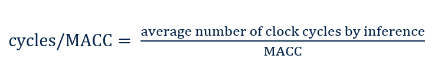

```
...
Results for 10 inference(s) @480/240MHz (macc:336084)
 device      : 0x450/STM32H743/753 and STM32H750 @480MHz/240MHz (FPU is present) lat=4 Core:I$/D$
 duration    : 4.522 ms (average)
 CPU cycles  : 2170476 (average)
 cycles/MACC : 6.46 (average for all layers)
...
```

## Memory-related metrics

When a model is rendered (refer to [3], “Analyze command” section), two main memory-related metrics (`'weights (ro)'` or `'ROM'` and `'activations (rw)'` or `'RAM'`) are reported to know the size of the memory which is requested to integrate the generated C-files. Please refer to [5], *“AI buffers and privileged placement”* section to have more details about the integration aspects. Note that the generation of the relocatable binary file (refer to [9]) allows to have more details about the final requested memory layout. Requested size of the AI .bss/.data/.rodata/.text sections for the kernels and network C-structures are also reported.

```
Runtime memory layout (series="stm32f4")
--------------------------------------------------------------------------------
section      size (bytes)
--------------------------------------------------------------------------------
header                100 *
txt                 7,864      network+kernel
rodata                128      network+kernel
data                1,756      network+kernel
bss                   132      network+kernel
got                   108 *
rel                   504 *
weights            15,560      network
--------------------------------------------------------------------------------
flash size         25,308 + 712 (+2.81%) *
ram size            1,888 + 108 (+5.72%) *
--------------------------------------------------------------------------------
bin size           26,024      binary image
act. size             192      activations buffer

(*) extra bytes for relocatable support
```

## Classification accuracy (acc)

*Classification accuracy* is what we usually mean, when the term *accuracy* is used. *ACC* is the ratio between of correct predictions to the total number of inputs. This indicator evaluates the performance of the *classifier* model, if a *regressor* type is passed, the *ACC* is **NOT** calculated and `n.a.` value is reported.

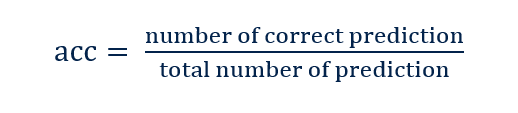

```python
import numpy as np
from sklearn.metrics import accuracy_score

def acc(ref, pred):
  """Classification accuracy (ACC)."""
  return accuracy_score(np.argmax(ref, axis=1), np.argmax(pred, axis=1))
```

## Mean Absolute Error (mae)

*MAE* is the average of the difference between the original value (or reference value, Rj) and the predicted value Pj. It gives the measure of how far the predictions were from the actual output. However, they don’t gives any idea of the direction of the error i.e. whether we are under predicting the data or over predicting the data. *MAE* is computed for the flattened array (element-wise along the array), returning a scalar value. If [R] is not provided [R’] is used.

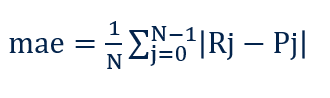

```python
import numpy as np

def mae(ref, pred):
  """Return Mean Absolute Error (MAE)."""
  return (np.abs(ref - pred).astype(np.float64)).mean()
```

## Root Mean Square Error (rmse)

*RMSE* is quite similar to *MAE*, the only difference being that *RMSE* takes the average of the square of the difference between the original values and the predicted values. As, we take square of the error, the effect of larger errors become more pronounced then smaller error, hence the model can now focus more on the larger errors. *RMSE* is computed for the flattened array (element-wise along the array), returning a scalar value. If [R] is not provided [R’] is used.

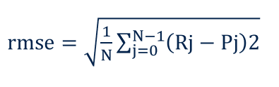

```python
import numpy as np

def rmse(ref, pred):
  """Return Root Mean Squared Error (RMSE)."""
  return np.sqrt(((ref - pred).astype(np.float64) ** 2).mean())
```

## L2 relative error (l2r)

*L2r* is the scalar value of the relative 2-norm or Euclidean distance between the generated values of the original model [R’] and the C-model [P]. This metric is only used with a 32b float model. When possible, this metric is also reported for the output of a C-layer matching with the original layer (refer to [3], *“L2r error report”* sub-section).

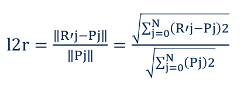

```python
import numpy as np

def l2r(ref, pred):
  """Compute L2 relative error"""
  def magnitude(v):
    return np.sqrt(np.sum(np.square(v).flatten()))
  mag = magnitude(pred) + np.finfo(np.float32).eps
  return magnitude(ref - pred) / mag
```

## Confusion matrix (CM)

When custom outputs are provided and the model is considered as a classifier, a confusion matrix is reported for the C-model and the reference model. It describes the complete performance of the model. Note that if a *regressor* type is passed, the confusion matrix is **NOT** calculated only the RMSE and MAE metrics are reported.

```
8 classes (50 samples)
------------------------------------------------
C0         4    .    .    .    .    .    .    .
C1         .    9    .    .    .    .    .    .
C2         .    .    6    .    .    .    .    .
C3         .    .    .    7    .    .    .    .
C4         .    .    .    .    5    .    .    .
C5         .    .    .    .    .    6    .    .
C6         .    .    .    .    .    .    7    .
C7         .    .    .    .    .    .    .    6
```

*X-Cross* confusion matrix or accuracy uses the outputs of the reference model to build the ground truth values. They are used to evaluate and to compare the performance of the C-model.

**Limitation** — The confusion matrix is only displayed when the number of class is lower or equal to 20.

# Use cases

## 32b float model - Input samples only

Default case, where only the input values are used to evaluate the generated C-model implementing a 32b float model. The same inputs [I] (random data or custom data) are used to feed the original model and the generated C-model. The outputs [P] and [R’] are mainly used to build the *L2r* error in this case. However, [R’] is also used as reference to compute the X-cross metrics: *ACC*, *RMSE* and *MAE*. These metrics (and associated confusion matrix) allow to enhance the *L2r* metric with additional indicators, in particular when random data are used and compression factor is applied.

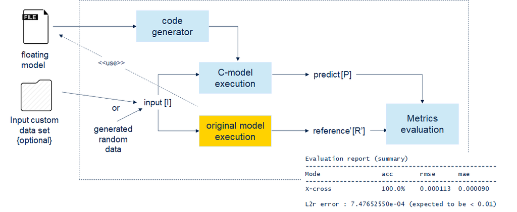

Figure 1: 32b float model with input samples only

Typical output during the execution of the `'validate'` command with random inputs.

```
$ stm32ai validate -m <modified_model_file>.h5 --full
...
-- Setting inputs (and outputs) data
Using random inputs, shapes=[(10, 99)] dtype=[float32]
-- Running X86 C-model
-- Running X86 C-model - done (elapsed time 0.102s)
-- Running original model
-- Running original model - done (elapsed time 0.303s)

Saving data in "<output-directory-path>" folder
 creating "network_val_m_inputs_1.csv"  dtype=[float32]
 creating "network_val_c_inputs_1.csv"  dtype=[float32]
 creating "network_val_m_outputs_1.csv"  dtype=[float32]
 creating "network_val_c_outputs_1.csv"  dtype=[float32]
 creating "network_val_io.npz"

Cross accuracy report #1 (reference vs C-model)
----------------------------------------------------------------------------------------------------
NOTE: the output of the reference model is used as ground truth/reference value

 acc=100.00%, rmse=0.000000, mae=0.000000

 5 classes (10 samples)
 ---------------------------------
 C0        9    .    .    .    .
 C1        .    0    .    .    .
 C2        .    .    0    .    .
 C3        .    .    .    0    .
 C4        .    .    .    .    1


Evaluation report (summary)
------------------------------------------------------------
Mode                   acc       rmse      mae
------------------------------------------------------------
X-cross #1             100.00%   0.000000  0.000000

L2r error : 1.02767139e-07 (expected to be < 0.01)

Creating report file <output-directory-path>\network_validate_report.txt

Complexity/l2r error per-layer - macc=3,960 rom=15,560
----------------------------------------------------------------------------------------------------
id  layer (type)                macc                    rom                      l2r error
----------------------------------------------------------------------------------------------------
0   dense_1 (Dense)             |||||||||||||||  82.5%  ||||||||||||||||  84.8%  1.22358045e-07
1   activation_1 (Nonlinearity) |                 0.8%  |                  0.0%  1.22744325e-07 *
2   dense_2 (Dense)             ||||             12.5%  ||||              13.1%  1.12652899e-07
3   activation_2 (Nonlinearity) |                 0.4%  |                  0.0%  9.49384997e-08
4   dense_3 (Dense)             |                 1.9%  |                  2.1%  9.90144144e-08
5   activation_3 (Nonlinearity) |                 1.9%  |                  0.0%  1.02767139e-07
----------------------------------------------------------------------------------------------------

...
```

## 32b float model - Input/output samples

This case is the recommended validation flow to evaluate the generated C-model implementing a 32b float model. As reference samples are provided, all metrics for each models (reference and c-model) are computed including X-cross values for quick evaluation. For a classifier model, the provided outputs (ground truth values) are used to report the classification accuracy.

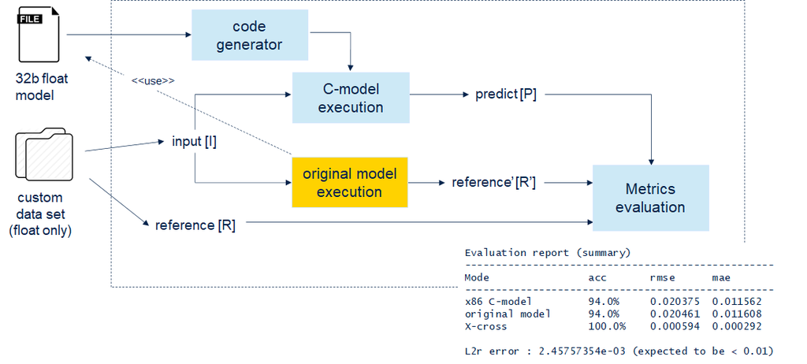

Figure 2: Floating-point model with IO values

Typical output during the execution of the “validate” command with custom data and compression factor.

```
$ stm32ai validate -m <model_file_path> -vi test_data.npz -c 8
...
Accuracy report #1 for the generated x86 C-model
------------------------------------------------------------------
NOTE: Computed against the provided ground truth values

acc=94.00%, rmse=0.0224, mae=0.0127

8 classes (50 samples)
------------------------------------------------
C0         4    .    .    .    .    .    .    .
C1         .    8    .    .    .    .    .    .
C2         .    .    6    .    .    .    1    .
C3         .    .    .    7    .    .    .    .
C4         .    .    .    .    5    .    .    .
C5         .    1    .    .    .    6    1    .
C6         .    .    .    .    .    .    5    .
C7         .    .    .    .    .    .    .    6

Accuracy report #1 for the reference model
------------------------------------------------------------------
NOTE: Computed against the provided ground truth values

acc=94.00%, rmse=0.0205, mae=0.0116

8 classes (50 samples)
------------------------------------------------
C0         4    .    .    .    .    .    .    .
C1         .    8    .    .    .    .    .    .
C2         .    .    6    .    .    .    1    .
C3         .    .    .    7    .    .    .    .
C4         .    .    .    .    5    .    .    .
C5         .    1    .    .    .    6    1    .
C6         .    .    .    .    .    .    5    .
C7         .    .    .    .    .    .    .    6

Cross accuracy report #1 (reference vs C-model)
------------------------------------------------------------------
NOTE: the output of the reference model is used as ground truth value

acc=100.00%, rmse=0.0063, mae=0.0034

8 classes (50 samples)
------------------------------------------------
C0         4    .    .    .    .    .    .    .
C1         .    9    .    .    .    .    .    .
C2         .    .    6    .    .    .    .    .
C3         .    .    .    7    .    .    .    .
C4         .    .    .    .    5    .    .    .
C5         .    .    .    .    .    6    .    .
C6         .    .    .    .    .    .    7    .
C7         .    .    .    .    .    .    .    6

Evaluation report (summary)
--------------------------------------------------
Mode                  acc       rmse      mae
--------------------------------------------------
x86 C-model  out=1    94.0%     0.022430  0.012718
original model out=1  94.0%     0.020461  0.011608
X-cross  #1           100.0%    0.006338  0.003373

L2r error : 2.63014436e-02 (expected to be < 0.01)
...
```

## Quantized model - Input samples only

[figure not shown]

Figure 3: Quantized TFLite model with input samples only

**Note** — For the quantized TFLite model, this is a typical case where we can have the same output values between the C-model and the original model: `X-cross #1 100%, RMSE=MAE=0.0`.

[figure not shown]

Figure 4: Quantized Keras model with input samples only

**Limitation** — int8/uint8 user data set files can be not used for the quantized Keras models.

Typical output during the execution of the `validate` command with random inputs for quantized model.

```
$ stm32ai validate -m <modified_model_file>.h5 -q <quant_file_desc>.json
...

Cross accuracy report #1 (reference vs C-model)
----------------------------------------------------------------------------------------------------
NOTE: the output of the reference model is used as ground truth/reference value

 acc=100.00%, rmse=0.006488, mae=0.002825, l2r=0.025700

 10 classes (10 samples)
 ----------------------------------------------------------
 C0        0    .    .    .    .    .    .    .    .    .
 C1        .    0    .    .    .    .    .    .    .    .
 C2        .    .    6    .    .    .    .    .    .    .
 C3        .    .    .    1    .    .    .    .    .    .
 C4        .    .    .    .    1    .    .    .    .    .
 C5        .    .    .    .    .    2    .    .    .    .
 C6        .    .    .    .    .    .    0    .    .    .
 C7        .    .    .    .    .    .    .    0    .    .
 C8        .    .    .    .    .    .    .    .    0    .
 C9        .    .    .    .    .    .    .    .    .    0

Evaluation report (summary)
------------------------------------------------------------------------------------------------
Mode          acc      rmse      mae       l2r       tensor
------------------------------------------------------------------------------------------------
X-cross #1    100.00%  0.006488  0.002825  0.025700  softmax_8 [ai_float, (1, 1, 10), m_id=12]
...
```

## TFLite Quantized model - Input/output samples

The input `[I]` of the model can be optionally converted/quantized before to feed the models. As the reference samples are provided, all metrics for each models are computed including X-cross values for quick evaluation.

[figure not shown]

Figure 5: Quantized TF lite model with IO values

Typical output during the execution of the `'validate'` command.

```
$ stm32ai validate -m <modified_model_file>.tflite -vi test_data.npz
...
Accuracy report #1 for the generated x86 C-model
----------------------------------------------------------------------------------------------------
NOTE: Computed against the provided ground truth values

 acc=99.22%, rmse=0.038794, mae=0.002396, l2r=0.123459

 10 classes (128 samples)
 ----------------------------------------------------------
 C0       12    .    .    .    .    .    .    .    .    .
 C1        .   19    .    .    .    .    .    .    .    .
 C2        .    .   16    .    .    .    .    .    .    .
 C3        .    .    .   11    .    .    .    .    .    .
 C4        .    .    .    .   15    .    .    .    .    .
 C5        .    .    .    .    .    7    .    .    .    .
 C6        .    .    .    .    .    .   10    .    .    .
 C7        .    .    .    .    .    .    .    9    .    .
 C8        .    .    .    .    .    .    .    .   18    .
 C9        .    .    .    .    .    1    .    .    .   10

Accuracy report #1 for the reference model
----------------------------------------------------------------------------------------------------
NOTE: Computed against the provided ground truth values

 acc=99.22%, rmse=0.038794, mae=0.002396, l2r=0.123459

 10 classes (128 samples)
 ----------------------------------------------------------
 C0       12    .    .    .    .    .    .    .    .    .
 C1        .   19    .    .    .    .    .    .    .    .
 C2        .    .   16    .    .    .    .    .    .    .
 C3        .    .    .   11    .    .    .    .    .    .
 C4        .    .    .    .   15    .    .    .    .    .
 C5        .    .    .    .    .    7    .    .    .    .
 C6        .    .    .    .    .    .   10    .    .    .
 C7        .    .    .    .    .    .    .    9    .    .
 C8        .    .    .    .    .    .    .    .   18    .
 C9        .    .    .    .    .    1    .    .    .   10

Cross accuracy report #1 (reference vs C-model)
----------------------------------------------------------------------------------------------------
NOTE: the output of the reference model is used as ground truth/reference value

 acc=100.00%, rmse=0.000000, mae=0.000000, l2r=0.000000

 10 classes (128 samples)
 ----------------------------------------------------------
 C0       12    .    .    .    .    .    .    .    .    .
 C1        .   19    .    .    .    .    .    .    .    .
 C2        .    .   16    .    .    .    .    .    .    .
 C3        .    .    .   11    .    .    .    .    .    .
 C4        .    .    .    .   15    .    .    .    .    .
 C5        .    .    .    .    .    8    .    .    .    .
 C6        .    .    .    .    .    .   10    .    .    .
 C7        .    .    .    .    .    .    .    9    .    .
 C8        .    .    .    .    .    .    .    .   18    .
 C9        .    .    .    .    .    .    .    .    .   10


Evaluation report (summary)
--------------------------------------------------------------------------------------------------
Mode                 acc      rmse      mae       l2r       tensor
--------------------------------------------------------------------------------------------------
x86 C-model #1       99.22%   0.038794  0.002396  0.123459  nl_5_fmt [ai_i8, (1, 1, 10), m_id=5]
original model #1    99.22%   0.038794  0.002396  0.123459  nl_5_fmt [ai_i8, (1, 1, 10), m_id=5]
X-cross #1           100.00%  0.000000  0.000000  0.000000  nl_5_fmt [ai_i8, (1, 1, 10), m_id=5]
...
```

## Model with multiple IO

All metrics are calculated independently for each outputs including the `L2r` for the 32b float model.

```
$ stm32ai validate -m <model_with_2_outputs>
...
Cross accuracy report #1 (reference vs C-model)
------------------------------------------------------------------
NOTE: the output of the reference model is used as ground truth value

acc=100.00%, rmse=0.0000, mae=0.0000

Cross accuracy report #2 (reference vs C-model)
------------------------------------------------------------------
NOTE: the output of the reference model is used as ground truth value

acc=100.00%, rmse=0.0000, mae=0.0000
...
Evaluation report (summary)
-------------------------------------------------------------------------------------------------
Mode          acc      rmse      mae       l2r       tensor
-------------------------------------------------------------------------------------------------
X-cross #1    n.a.     0.000000  0.000000  0.000000  add_1 [ai_float, (16, 16, 3), m_id=7]
X-cross #2    n.a.     0.000000  0.000000  0.000000  multiply_1 [ai_float, (16, 16, 3), m_id=7]

L2r error : 0.00000000e+00 (expected to be < 0.01)
...
```

```
$ stm32ai validate -m <model_with_2_outputs> -vi test_multiple_io.npz
...
Evaluation report (summary)
--------------------------------------------------------------------------------------------------------
Mode                 acc      rmse      mae       l2r       tensor
--------------------------------------------------------------------------------------------------------
x86 C-model #1       n.a.     0.000000  0.000000  0.000000  add_1 [ai_float, (16, 16, 3), m_id=7]
x86 C-model #2       n.a.     0.000000  0.000000  0.000000  multiply_1 [ai_float, (16, 16, 3), m_id=7]
original model #1    n.a.     0.000000  0.000000  0.000000  add_1 [ai_float, (16, 16, 3), m_id=7]
original model #2    n.a.     0.000000  0.000000  0.000000  multiply_1 [ai_float, (16, 16, 3), m_id=7]
X-cross #1           n.a.     0.000000  0.000000  0.000000  add_1 [ai_float, (16, 16, 3), m_id=7]
X-cross #2           n.a.     0.000000  0.000000  0.000000  multiply_1 [ai_float, (16, 16, 3), m_id=7]

L2r error : 0.00000000e+00 (expected to be < 0.01)
```

```
Complexity/l2r error per-layer - macc=4,608 rom=0
----------------------------------------------------------------------------------------------------
id  layer (type)         macc                      rom                   l2r error
----------------------------------------------------------------------------------------------------
3   maximum_1 (Eltwise)  |||||||||||||||||  33.3%  |                0.0%
4   minimum_1 (Eltwise)  |||||||            16.7%  |                0.0%
5   add_1 (Eltwise)      |||||||            16.7%  |                0.0%  0.00000000e+00 *
6   subtract_1 (Eltwise) |||||||            16.7%  |                0.0%
7   multiply_1 (Eltwise) |||||||            16.7%  |                0.0%  0.00000000e+00 *
----------------------------------------------------------------------------------------------------
```

# Post-processing example

Following log is the output of a custom Python script to read the generated samples and to build new element-wise metrics: `'variance'` and `'f1_score'` (thanks to the *numpy* and *sklearn.metrics* Python modules). `'acc'`, `'rmse'`, `'mae'` and `'l2r'` are also provided to illustrate how these metrics are computed.

```
$ python custom_metrics.py
Read generated NPZ file "./stm32ai_output\network_val_io.npz"...
Read generated CSV files "./stm32ai_output\network_val_*.csv"...
Read reference NPZ file "network_reference.npz"...

Evaluation report
--------------------------------------------------------------------------------
               acc       rmse      mae       var       f1_score  l2r
--------------------------------------------------------------------------------
C-model        94.0%     0.149257  0.082441  0.022333  0.932265  0.44756502
original model 94.0%     0.020461  0.011608  0.000420  0.944341  0.08464438
X-cross        92.0%     0.156579  0.087279  0.024577  0.919234  0.46952036
```

Full code of the custom Python script.

```python
# -*- coding: utf-8 -*-
"""
Implement custom metrics
"""
from __future__ import absolute_import
from __future__ import division
from __future__ import print_function

import os
import numpy as np
import argparse

from sklearn.metrics import mean_squared_error
from sklearn.metrics import accuracy_score
from sklearn.metrics import f1_score

OUTPUT_DIR = './stm32ai_output'
NETWORK_NAME = 'network'
REFERENCE_NPZ = 'network_reference.npz'

# metrics

def mse(ref, pred):
  """Return Mean Squared Error (MSE)."""
  return ((ref - pred).astype(np.float64) ** 2).mean()

def rmse(ref, pred):
  """Return Root Mean Squared Error (RMSE)."""
  return np.sqrt(((ref - pred).astype(np.float64) ** 2).mean())

def mae(ref, pred):
  """Return Mean Absolute Error (MAE)."""
  return (np.abs(ref - pred).astype(np.float64)).mean()

def var(ref, pred):
  """Return Variance"""
  return np.var((ref - pred), dtype=np.float64, ddof=1)

def acc(ref, pred):
  """Classification accuracy (ACC)."""
  return accuracy_score(np.argmax(ref, axis=1), np.argmax(pred, axis=1))

def f1_s(ref, pred, average='macro'):
  """Compute the F1 score, also known as balanced F-score or F-measure (F1)"""
  return f1_score(np.argmax(ref, axis=1), np.argmax(pred, axis=1), average=average)

def l2r(ref, pred):
  """Compute L2 relative error"""
  def magnitude(v):
    return np.sqrt(np.sum(np.square(v).flatten()))
  mag = magnitude(pred) + np.finfo(np.float32).eps
  return magnitude(ref - pred) / mag

# read the generated inputs and predicted samples (origninal & C models)

fname = os.path.join(OUTPUT_DIR, NETWORK_NAME + '_val_io.npz')
print('Read generated NPZ file "{}"...'.format(fname))
arrays = np.load(fname)

i_  = arrays['m_inputs_1']
ic_  = arrays['c_inputs_1']
p_  = arrays['c_outputs_1']
pm_ = arrays['m_outputs_1']

fname = os.path.join(OUTPUT_DIR, NETWORK_NAME + '_val_*.csv')
print('Read generated CSV files "{}"...'.format(fname))

fname = os.path.join(OUTPUT_DIR, NETWORK_NAME + '_val_m_inputs_1.csv')
i_csv_ = np.atleast_2d(np.genfromtxt(fname, delimiter=','))
fname = os.path.join(OUTPUT_DIR, NETWORK_NAME + '_val_c_inputs_1.csv')
ic_csv_ = np.atleast_2d(np.genfromtxt(fname, delimiter=','))
fname = os.path.join(OUTPUT_DIR, NETWORK_NAME + '_val_c_outputs_1.csv')
p_csv_ = np.atleast_2d(np.genfromtxt(fname, delimiter=','))
fname = os.path.join(OUTPUT_DIR, NETWORK_NAME + '_val_m_outputs_1.csv')
pm_csv_ = np.atleast_2d(np.genfromtxt(fname, delimiter=','))

l_csv = len(i_csv_)

# read reference samples

print('Read reference NPZ file "{}"...'.format(REFERENCE_NPZ))

fname = REFERENCE_NPZ
arrays = np.load(fname)

i_ref = arrays['in_0']
r_ref = arrays['out_0']

# reshape the _csv data

i_csv_ = i_csv_.reshape((-1,) + i_.shape[1:])
p_csv_ = p_csv_.reshape((-1,) + p_.shape[1:])
pm_csv_ = pm_csv_.reshape((-1,) + pm_.shape[1:])

# calculate metrics

def build_metrics(ref, pred):
  res = {}
  res['acc'] = acc(ref, pred)
  res['var'] = var(ref, pred)
  res['f1_score'] = f1_s(ref, pred)
  res['rmse'] = rmse(ref, pred)
  res['mae'] = mae(ref, pred)
  res['mse'] = mse(ref, pred)
  res['l2r'] = l2r(ref, pred)
  return res

def print_metrics(name, ref, pred):
  res = build_metrics(ref, pred)
  str = '{:15s}'.format(name)
  _acc = '{:.1f}%'.format(res['acc'] * 100.0)
  str += '{:10s}'.format(_acc)
  str += '{:.6f}  '.format(res['rmse'])
  str += '{:.6f}  '.format(res['mae'])
  str += '{:.6f}  '.format(res['var'])
  str += '{:.6f}  '.format(res['f1_score'])
  str += '{:.8f}  '.format(res['l2r'])
  print(str)

print('\nEvaluation report')
print('-'*80)
print('               {:8s}  {:8s}  {:8s}  {:8s}  {:8s}  {:8s}'.format('acc', 'rmse',
          'mae', 'var', 'f1_score', 'l2r'))
print('-'*80)
print_metrics('C-model', r_ref, p_)
print_metrics('original model', r_ref, pm_)
print_metrics('X-cross', pm_, p_)
```

# References

| [1] | X-CUBE-AI - *AI expansion pack for STM32CubeMX* https://www.st.com/en/embedded-software/x-cube-ai.html |
| --- | --- |
| [2] | User manual - Getting started with X-CUBE-AI Expansion Package for Artificial Intelligence (AI) [(pdf)](https://www.st.com/resource/en/user_manual/dm00570145.pdf) |
| [3] | stm32ai - Command Line Interface (link) |
| [4] | Supported Deep Learning toolboxes and layers (link) |
| [5] | Embedded inference client API (link) |
| [6] | Evaluation report and metrics (link) |
| [7] | FAQs (link) |
| [8] | Quantization and quantize command (link) |
| [9] | Relocatable binary network support (link) |

# Revision history

| Date | version | changes |
| --- | --- | --- |
| **2019-07-02** | r1.0 | initial version |
| **2019-09-20** | r1.1 | X-CUBE-AI 4.1 update, add MACC/ROM/RAM metrics + Quantized TF lite model. |
| **2019-12-06** | r1.2 | X-CUBE-AI 5.0 update, add network with multiple IO. |
| **2020-05-12** | r1.3 | X-CUBE-AI 5.1 update, add int8/uint8 support for input validation data files, complete the description of the metrics |
| **2020-09-15** | r1.4 | X-CUBE-AI 5.2 update, L2r metric is always calculated. Name/shape of the output tensor is added with the results |

Embedded Documentation - **Evaluation report and metrics**  
X-CUBE-AI Expansion Package  
r1.4 - AI PLATFORM r5.2.0 (Embedded Inference Client API 1.1.0) - Command Line Interface r1.4.0

Information in this document is provided solely in connection with ST products. The contents of this document are subject to change without prior notice.  
© Copyright STMicroelectronics 2020. All rights reserved. www.st.com